### Q1 For part A and B

##### PlantGrowth is a dataset in R that contains crop weights of a control group and two treatment groups.

```r
#Code to Get Data
library(datasets)
data(PlantGrowth)
```

##### Perform the following operations: Create two separate datasets: dataset1 contains datapoints of treatment 1 group and control group, and dataset2 contains datapoints of treatment 2 group with the control group.

### A) Now compute the difference estimator for each dataset that were just created. (treatment 1 vs control group for dataset1, and treatment 2 vs control group for dataset2)

```r
library(dplyr)
# create two datasets
df1 <- PlantGrowth %>% filter(group=="ctrl"|group=="trt1")
df2 <- PlantGrowth %>% filter(group=="ctrl"|group=="trt2")

# fit linear regression
model1 <- lm(weight ~ ., data = df1)
summary(model1)
```

```
##
## Call:
## lm(formula = weight ~ ., data = df1)
##
## Residuals:
##     Min      1Q  Median      3Q     Max
## -1.0710 -0.4938  0.0685  0.2462  1.3690
##
## Coefficients:
##             Estimate Std. Error t value Pr(>|t|)
## (Intercept)   5.0320     0.2202  22.850 9.55e-15 ***
## grouptrt1    -0.3710     0.3114  -1.191    0.249
## ---
## Signif. codes:  0 '***' 0.001 '**' 0.01 '*' 0.05 '.' 0.1 ' ' 1
##
## Residual standard error: 0.6964 on 18 degrees of freedom
## Multiple R-squared:  0.07308,    Adjusted R-squared:  0.02158
## F-statistic: 1.419 on 1 and 18 DF,  p-value: 0.249
```

```r
model2 <- lm(weight ~ ., data = df2)
summary(model2)
```

```
##
## Call:
## lm(formula = weight ~ ., data = df2)
##
## Residuals:
##    Min     1Q Median     3Q    Max
## -0.862 -0.410 -0.006  0.280  1.078
##
## Coefficients:
##             Estimate Std. Error t value Pr(>|t|)
## (Intercept)   5.0320     0.1637  30.742   <2e-16 ***
## grouptrt2     0.4940     0.2315   2.134   0.0469 *
## ---
## Signif. codes:  0 '***' 0.001 '**' 0.01 '*' 0.05 '.' 0.1 ' ' 1
##
## Residual standard error: 0.5176 on 18 degrees of freedom
## Multiple R-squared:  0.2019, Adjusted R-squared:  0.1576
## F-statistic: 4.554 on 1 and 18 DF,  p-value: 0.04685
```

### B) From the PlantGrowth dataset what is the average crop weight of the control group, treatment 1 group, and treatment 2 group, comment on which group has the highest average?

5.03,4.66 and 5.53 and Treatment 2 group has the highest average The intercept (5.03) is the average crop weight of the control group. Treatment Group 1 has diff estimator of -0.37 which makes the average weight for that group 4.66, and Treatment Group 2 has diff estimator of 0.49 which makes the average weight for that group 5.53.

### Q1 Part C,D & E

##### Use the Dataset “Min_Wage.csv” and the information below to answer part C, D and E.

##### The Minimum Wage Law protects the right of workers to get a minimum wage. Consider a scenario where the law of minimum wage was changed just in the state of New Jersey (i.e., law has not been changed in other states). We want to use the data from company XYZ to observe the difference in hours worked by full time employees in New Jersey before and after the law was changed.

##### • The variable ‘State’ indicates the citizenship of the worker, i.e., State = New Jersey ,the worker is from NJ, else worker is not from NJ (is from Philadelphia).

##### • The variable fte contains the number of hours worked by full time employee.

##### • The variable d indicates whether or not the data was collected before or after the law changed, i.e. d = 1 indicates the data was collected after the law was changed, and d = 0 indicates the data was collected before the law was changed.

### C) In the above problem, classify the workers into four groups and assign the corresponding group with the group title (A,B,C and D) where the group titles are as follows:

##### Note: This is a theoretical question, you just need to identify each group with a short description of what the group is. You don’t need to create a column categorizing the datapoints into groups.

A - Worker’s from Philadelphia before the law was changed.  
B - Worker’s from New Jersey before the law was changed.  
C - Worker’s from Philadelphia after the law was changed.  
D - Worker’s from New Jersey after the law was changed.

### D) To estimate the difference in difference we need four averages for the above categorized groups i.e., control group before change, control group after change, treatment group before change and treatment group after change. Compute the following

### (i)Calculate the mean of the ‘fte’ variable for each of the four groups in R and print them

### (ii) Using these averages estimate the value of the difference in difference

```r
min_wage <- read.csv("Min_Wage.csv")
min_wage<- min_wage%>%
mutate(nj = ifelse(State == "New Jersey",1,0))
min_wage $d = as.numeric(min_wage $d)
min_wage $fte = as.numeric(min_wage $fte)

# The active period of Law change is indicated by variable 'd'
# The citizenship of New Jersey is indicated by variable 'nj'

a = sapply(subset(min_wage, nj == 0 & d == 0, select=fte), mean)
b = sapply(subset(min_wage, nj == 1 & d == 0, select=fte), mean)
c = sapply(subset(min_wage, nj == 0 & d == 1, select=fte), mean)
d = sapply(subset(min_wage, nj == 1 & d == 1, select=fte),mean)

# Difference in difference parameter
DID = (d-b)-(c-a)
print(DID)  #Answer = 2.75
```

```
##  fte
## 2.75
```

### E) Estimate the DID (Difference in Difference) using regression model.

```r
# Using Regression
model = lm(fte ~ nj+ d + nj*d,data = min_wage)
summary(model)
```

```
##
## Call:
## lm(formula = fte ~ nj + d + nj * d, data = min_wage)
##
## Residuals:
##     Min      1Q  Median      3Q     Max
## -21.097  -6.472  -0.931   4.603  64.569
##
## Coefficients:
##             Estimate Std. Error t value Pr(>|t|)
## (Intercept)   23.380      1.098  21.288   <2e-16 ***
## nj            -2.949      1.224  -2.409   0.0162 *
## d             -2.283      1.553  -1.470   0.1419
## nj:d           2.750      1.731   1.588   0.1126
## ---
## Signif. codes:  0 '***' 0.001 '**' 0.01 '*' 0.05 '.' 0.1 ' ' 1
##
## Residual standard error: 9.511 on 764 degrees of freedom
## Multiple R-squared:  0.007587,   Adjusted R-squared:  0.00369
## F-statistic: 1.947 on 3 and 764 DF,  p-value: 0.1206
```

```r
#Difference in difference estimator is the coefficient of the interaction term which is 2.75
```

### Q2

##### For the following questions, use the dataset Berkshire.csv with the following variables:

##### Column (1): Date, Calendar Date

##### Column (2): BRKret, Berkshire Hathaway’s monthly return

##### Column (3): MKT, the return on the aggregate stock market

##### Column (4): RF, the risk free rate of return

##### You may/may not need the following dependencies:

##### “PerformanceAnalytics” package

##### Return data is in decimal format, 0.01=1%. Round all answers to the nearest hundredth, for example 12.34%.

### A)Find the standard deviation of Berkshire Hathaway over the sample period. (1 point)

```r
library(lubridate)
library(xts)
library(PerformanceAnalytics)
data <- read.csv("Berkshire.csv")
round(sd(data$BrkRet)*100,2)
```

```
## [1] 6.75
```

### B) Find Berkshire Hathaway’s average return over the sample period? Use arithmetic average (1 point)

```r
round(mean(data$BrkRet)*100,2)
```

```
## [1] 1.9
```

### C) By what percentage per month on average has Berkshire Hathaway outperformed the market? (1 point)

```r
round(mean(data$BrkRet)*100,2) - round(mean(data$MKT)*100,2)
```

```
## [1] 0.88
```

### D) $10,000 invested in Berkshire Hathaway at the start of the sample period would have GROWN TO ____ by the end of the sample period. (1 point)

##### (Hint: make sure to calculate how much the investment would have grown to, not how much it would grow by)

```r
#converting dates to standard YYYY-MM-DD format
data$Date <- mdy(data$Date)
#Sorting data by dates
data2<- data[order(data$Date),]
#create an xts dataset
All.dat <- xts(data2[,-1], order.by = data2$Date)
#Calculate Compound Return for the fund across all the data
Return.cumulative(All.dat$BrkRet,geometric = TRUE)
```

```
##                    BrkRet
## Cumulative Return 4143.99
```

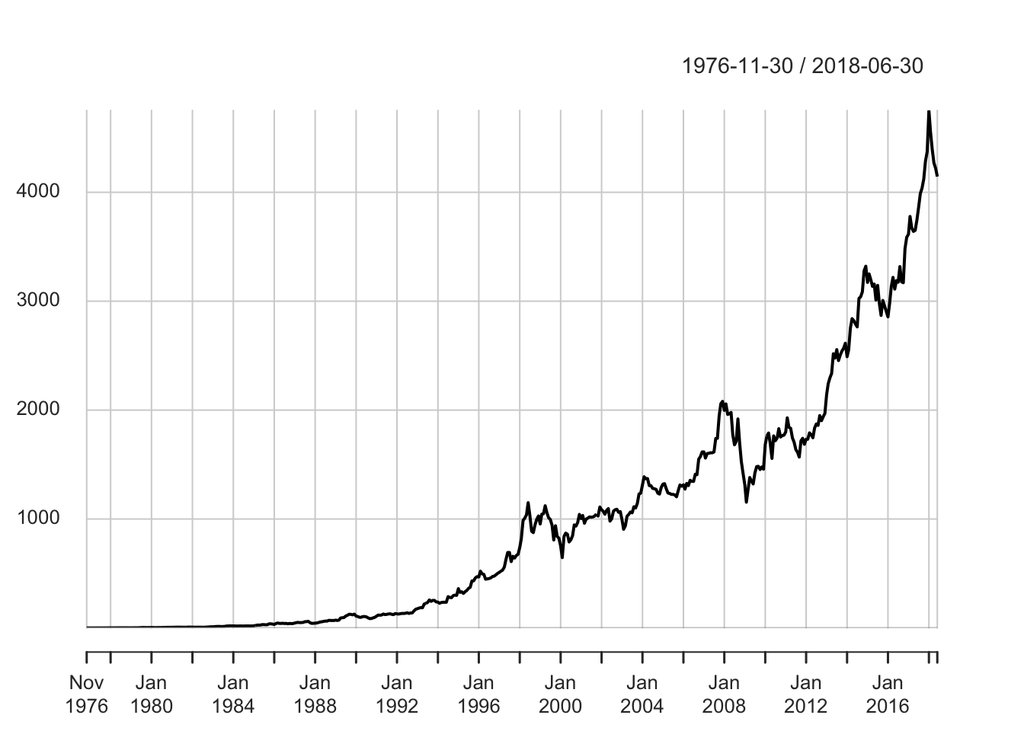

```r
cum_ret <- Return.cumulative(All.dat$BrkRet,geometric = TRUE)[1]

#Cumulative Returns chart over time
#Check chart in Plots Tab on bottom right in R Studio
chart.CumReturns(All.dat$BrkRet,wealth.index = FALSE, geometric = TRUE)
```

```r
10000 * (1+cum_ret)
```

```
## [1] 41449896
```

### E) Plot the cumulative return of Berkshire and Market across all years and include a legend. Describe your observation. (1 point)

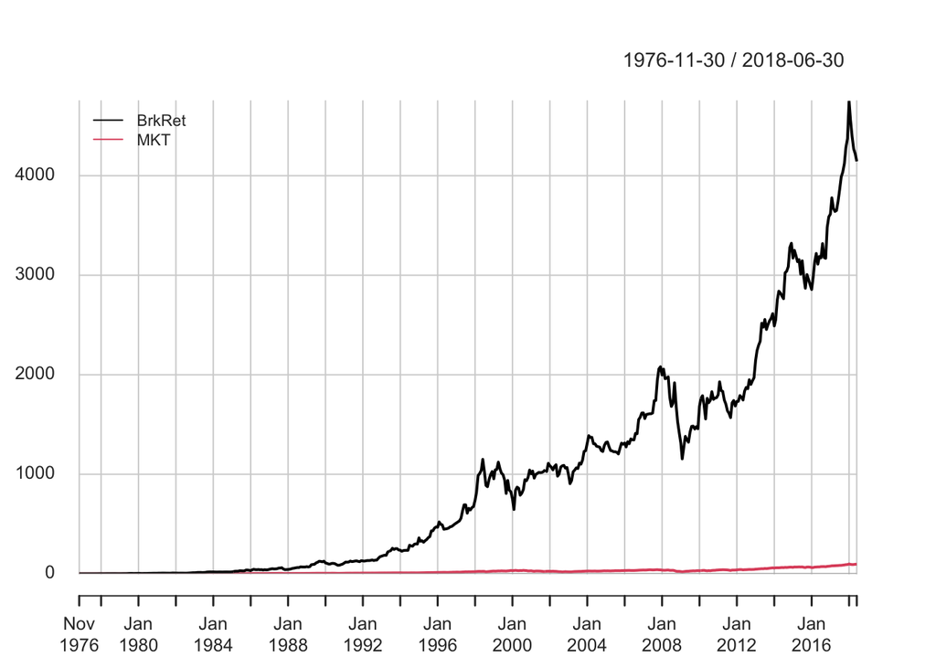

```r
dat2 <- All.dat[ , 1:2]
chart.CumReturns(dat2,wealth.index = FALSE, geometric = TRUE, legend.loc = "topleft")
```

```r
#Berkshire Hathaway’s return was significantly more than the market.

Return.cumulative(All.dat$MKT,geometric = TRUE)
```

```
##                        MKT
## Cumulative Return 96.22392
```

```r
Return.cumulative(All.dat$BrkRet,geometric = TRUE)
```

```
##                    BrkRet
## Cumulative Return 4143.99
```